# POLS 1600: Final Paper Template

Author

Group XX: Member names here

Published

# 1 Introduction

This document provides a template for the structure of your final paper for POLS 1600.

**Replace this markdown text with the introduction to your paper that:**

- Clearly articulates your group’s research question
- Lays out the theoretical framework that motivates your inquiry
- Describes your empirical strategy
- Provides an outline of the rest of the paper and previews your results.

# 2 Theory and Expectations

In this section you will develop on your theoretical framework to develop a set of testable empirical implications that address your broader research question.

This section should begin by explaining the following:

- What is the phenomenon you are studying? (Research Question/Outcome of Interest)
- Why should we care about this? (Context/Motivation/Importance)

Then it should turn to addressing:

- What are the factors scholars think explain this phenomenon? (Literature Review/Key predictors/Alternative explanations)

Which should lead to a discussion of

- What are the empirical implications of these claims? (Testable hypotheses)

# 3 Data

In this section you will describe your data.

- Identify the source or sources of your data
- Define the unit of analysis and number of observations in your data
- Explain how your key concepts (outcome variable, key predictors, covariates/alternative explanations) are measured
- Describe the distributions of these data using a table and/or figure(s).
- Interpret these distributions for your reader. What does a typical observation in the data look like. Are some data skewed. Are there big outliers?

Before you write anything in this section, you will want to adapt the code chunks below to:

- Set up the work space
- Load your data
- Recode and transform the data as needed
- Produce tables of summary statistics and figures

I’ve included code chunks in the .qmd file to demonstrate this process using data from the 2020 National Election Time Series Study.

However, you won’t see that code until in the knitted document until you get to the code appendix at the end.

For example, in the .qmd file, there is a code chunk here, labelled `setup`, for loading packages.

A code chunk here labelled `data` loading data

A code chunk here here labelled `recodes` recoding the data

A code chunk here labelled `descriptives` calculating some descriptive statistics, and producing some example figures, saved to objects called `fig1` and `fig2`

Finally, once I’ve created a data frame containing summary statistics, I use the `knitr` packages `kable` function, and functions from the `kableExtra` package to [format the table](https://cran.r-project.org/web/packages/kableExtra/vignettes/awesome_table_in_html.html)

The code chunk is labelled `sumtab` but you won’t see the R code itself, because in the YAML header at the top of the document, I’ve: set `include: false` to hide **all the R code and output** in the YAML header of the document

**When I want to display the results** of a particular chunk, I need to put `#| include: true` in the chunk’s argument.

**If I’m displaying a table** I need to set `results="asis"` to display just the results of `sumtab` exactly as they are (which in this chunk is a table formatted in html)

Descriptive Statistics

[output not shown]

**To display a figure** that I **have saved as an object** in a previous chunk, like `fig1`, I simply **print that object** on its own line in it’s own chunk and set `#| include: true`. I’ve added a caption to the figure, using the `fig.cap="Distribution of Trust in Government` argument of this the code chunk below

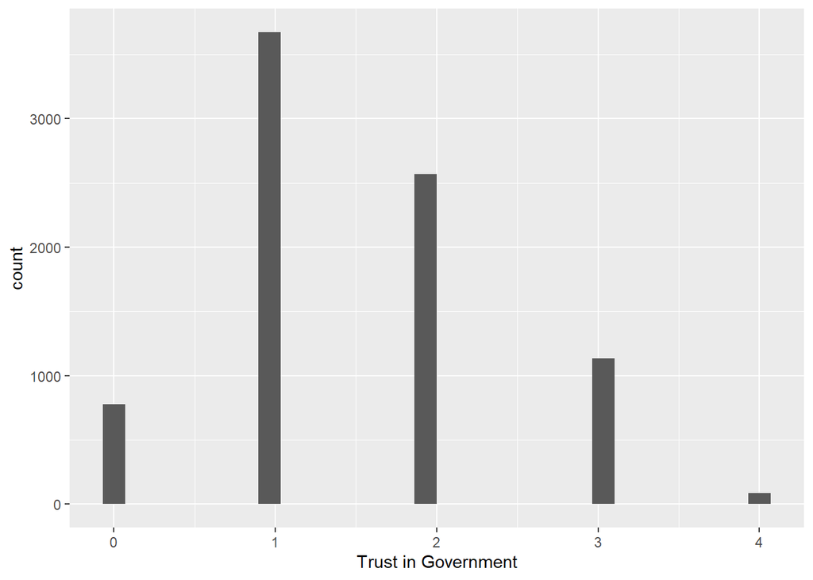

Figure 1: Distribution of Trust in Government

And similarly for `fig2`

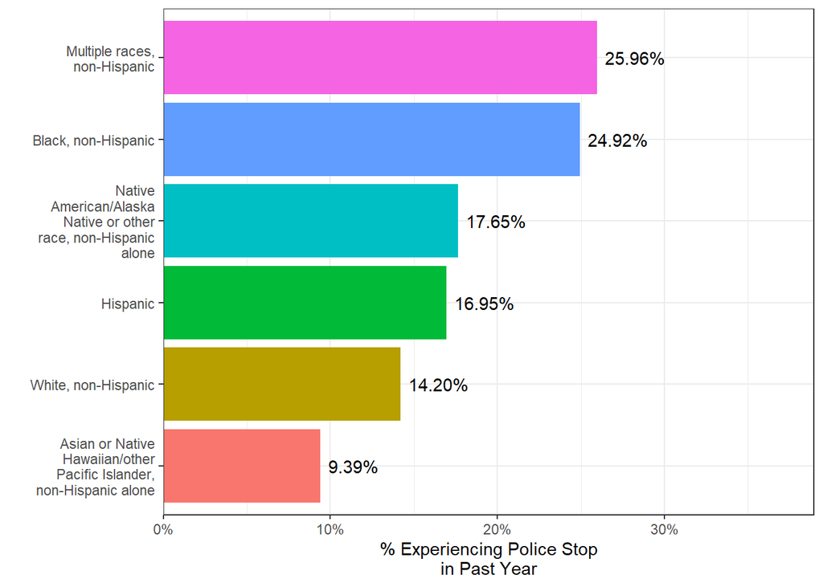

Figure 2: Police Stops by Race

And similarly for `fig3`

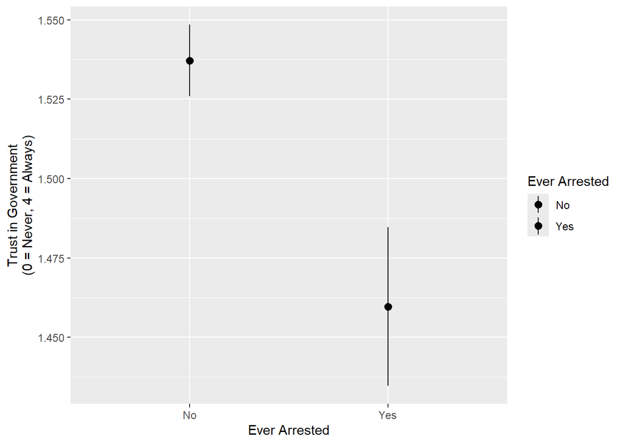

Figure 3: Average Trust in Government by Arrest Status

# 4 Design

Next, you will describe the empirical research design that you will use to test your expectations. You have two main tasks or goals for this section:

First you need to explain how you will to **test your theoretical expectations** in terms of the **empirical estimates of your model** (e.g. the regression coefficients of your linear models).

At a minimum, you will likely want to specify at least two models:

1. A baseline (bivariate) model

$$\text{Outcome} = \beta_0 + \beta_1 \times \text{Key Predictor} + \epsilon$$

2. A multiple regression model controlling for alternative explanations (things that predict both your outcome and key predictor)

$$\text{Outcome} = \beta_0 + \beta_1 \times \text{Key Predictor} + X\beta + \epsilon$$
Where $X\beta$ is a matrix containing one or more additional predictors representing alternative explanations. Again tell the reader how to interpret this model in relation to your baseline.

Second, in framing your expectations and explaining how you interpret your models you can use this section to **demonstrate your mastery of some of the key statistical concepts** from the course.

Show the reader that you understand:

- What the identifying assumptions of your design
- What linear regression is and how it works
- What it means to control for variables in a multiple regression
- How to quantify uncertainty in your estimates

You can also demonstrate your understanding of these concepts in the next section.

# 5 Results

Having described your data and mapped your theoretical expectations onto your empirical models, you will present your results.

This section should include the following:

- A regression table (or tables) presenting the coefficients from estimated models
- Interpretation of the the coefficients from these models in terms of your empirical expectations.
  - Are the results consistent with your expectations?
  - How and why do estimates vary from one model to the next?
  - How confident should we be in a given estimate?
  - Specifically, how should we interpret the confidence intervals and p-values associated with a given estimate?
- A figure that helps illustrate one of your key findings:
  - This will likely be a predicted values from one (or more) of your models, particularly if you are estimating a model with an interaction term, a polynomial term, or a generalized linear model.

In general, I would encourage you to start from the simplest, likely bivariate model. Use this as a chance to explain the mechanics of linear regression, the interpretation of linear regression as linear estimated of the Conditional Expectation Function, and demonstrate your mastery of the concepts of confidence intervals and hypothesis testing.

Then turn results from more complicated models. Again provide a substantive interpretation the coefficients and possible changes sign, size, and/or significance of coefficients from one model to the next. Use this discussion to further demonstrate your understanding of what it means to control for variables – both from a technical and substantive perspective.

Finally use a figure (or figures) to help illustrate the substantive interpretation of your results. (e.g. How much is your outcome predicted to change if some key predictor moved from one standard deviation below its mean to one standard deviation above)

Again, **before you do any writing** in this section, you should have code that:

- Estimates models
- Present your results in one or more regression tables

And produce a plot of predicted values to illustrate a key relationship

Here’s where you would write the interpretation of `fig4`, which is displayed in by the code chunk below

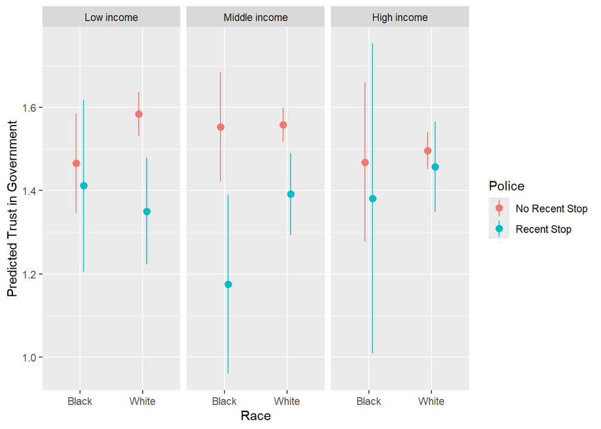

Figure 4: Differences in Trust by Race, Class, and Contact with the Police

# 6 Conclusion

Finally, conclude by summarizing the results of your project.

- What did you set out to learn?
- What did you find?
- What are some the strengths and weaknesses of your approach?
- What should future research on this topic look like?
- A list of correctly formatted references

## 6.1 References

I’d use a bulleted list to format your references. Aim for at least three, academic citations.

- Citrin, J. (1974). Comment: The political relevance of trust in government. *American Political Science Review*, 68(3), 973-988.
- Lerman, Amy E., and Vesla M. Weaver. (2014) *Arresting Citizenship*. University of Chicago Press, 2014.
- Jeong, J., & Han, S. (2020). Trust in police as an influencing factor on trust in government: 2SLS analysis using perception of safety. *Policing: An International Journal.*